# The EM Algorithm for MMLE, Step by Step

2026-02-15

## The EM Algorithm: Overview

The EM algorithm alternates between two steps:

| Step | What it does | Analogy |
| --- | --- | --- |
| **E-step** | Uses current item parameter guesses to figure out how examinees are distributed across the ability scale | “If these were the true item parameters, where would each examinee likely fall?” |
| **M-step** | Uses that ability distribution to re-estimate item parameters | “Given where we think examinees fall, what item parameters best fit the responses?” |

We repeat until the estimates stop changing.

## The Data: LSAT-6

- **1000 examinees**, **5 dichotomous items**, **32 unique response patterns**

8 Most Common Response Patterns

| Pattern | Freq |
| --- | --- |
| 11111 | 298 |
| 11011 | 173 |
| 10011 | 81 |
| 10111 | 80 |
| 11101 | 61 |
| 11001 | 56 |
| 10001 | 29 |
| 10101 | 28 |

## Initial Setup

**2PL model** with intercept/slope parameterization:

\[P_i(\theta) = \frac{1}{1 + \exp(-(d_i + a_i\theta))}\]

**Starting values:** all intercepts \(d_i = 0\), all slopes \(a_i = 1\)

**Quadrature:** 10 nodes from \(-4\) to \(+4\) with weights from the standard normal

These starting values treat all items as identical — the *data* will differentiate them.

## E-Step 1: Likelihood at Each Node

For each response pattern \(l\) at each quadrature node \(X_k\):

\[L_l(X_k) = \prod_{i=1}^{n} P_i(X_k)^{u_{li}} Q_i(X_k)^{1-u_{li}}\]

“How probable is this response pattern if the examinee’s ability were exactly \(X_k\)?”

Pattern 22 {1,0,1,0,1}: Likelihood at each node

| X_k | L_l(X_k) |
| --- | --- |
| -4.0000 | 0.00000561 |
| -3.1111 | 0.00007111 |
| -2.2222 | 0.00076087 |
| -1.3333 | 0.00568600 |
| -0.4444 | 0.02214009 |
| 0.4444 | 0.03452866 |
| 1.3333 | 0.02157010 |
| 2.2222 | 0.00702097 |
| 3.1111 | 0.00159618 |
| 4.0000 | 0.00030636 |

## E-Step 2: Marginal Probability

Sum over nodes, weighted by quadrature weights:

\[P_l = \sum_{k=1}^{q} L_l(X_k) \cdot A(X_k)\]

This is the **marginal likelihood** of pattern \(l\) — the probability of seeing that pattern averaged across all ability levels.

| Pattern | Freq | Marginal Prob |
| --- | --- | --- |
| 11111 | 298 | 0.0955352 |
| 11011 | 173 | 0.0360619 |
| 10011 | 81 | 0.0224199 |
| 10111 | 80 | 0.0360619 |
| 11101 | 61 | 0.0360619 |
| 11001 | 56 | 0.0224199 |
| 10001 | 29 | 0.0224199 |
| 10101 | 28 | 0.0224199 |

## E-Step 3: Posterior Probabilities

Apply Bayes’ theorem at each node:

\[P(X_k \mid \mathbf{u}_l) = \frac{L_l(X_k) \cdot A(X_k)}{P_l}\]

Pattern 22 {1,0,1,0,1}; \(P_l\) = 0.02241993

| \(X_k\) | \(L_l(X_k)\) | \(A(X_k)\) | \(L \times A\) | Posterior |
| --- | --- | --- | --- | --- |
| -4.0000 | 0.00000561 | 0.000119 | 0.00000000 | 0.00000003 |
| -3.1111 | 0.00007111 | 0.002805 | 0.00000020 | 0.00000890 |
| -2.2222 | 0.00076087 | 0.030020 | 0.00002284 | 0.00101879 |
| -1.3333 | 0.00568600 | 0.145800 | 0.00082902 | 0.03697690 |
| -0.4444 | 0.02214009 | 0.321300 | 0.00711361 | 0.31728951 |
| 0.4444 | 0.03452866 | 0.321300 | 0.01109406 | 0.49483018 |
| 1.3333 | 0.02157010 | 0.145800 | 0.00314492 | 0.14027339 |
| 2.2222 | 0.00702097 | 0.030020 | 0.00021077 | 0.00940098 |
| 3.1111 | 0.00159618 | 0.002805 | 0.00000448 | 0.00019970 |
| 4.0000 | 0.00030636 | 0.000119 | 0.00000004 | 0.00000163 |

## E-Step 3: Posterior (Visual)

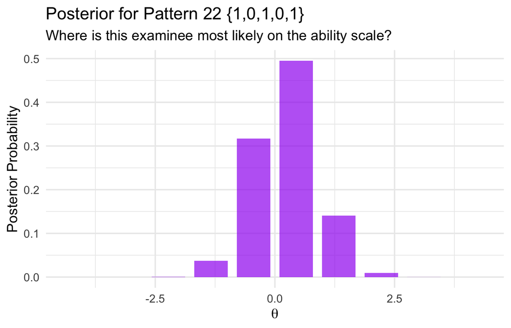

## E-Step 4: The “Artificial Data”

Aggregate across all examinees (weighted by pattern frequency \(f_l\)):

\[\bar{n}_k = \sum_{l=1}^{s} f_l \cdot P(X_k \mid \mathbf{u}_l) \quad \text{(expected examinees at node } k\text{)}\]

\[\bar{r}_{ik} = \sum_{l=1}^{s} u_{li} \cdot f_l \cdot P(X_k \mid \mathbf{u}_l) \quad \text{(expected correct on item } i \text{ at node } k\text{)}\]

These play the same role as the observed frequencies in the JMLE estimation equations.

## E-Step 4: Artificial Data Table

Artificial data from E-Step (Cycle 1)

| \(X_k\) | \(\bar{n}_k\) | \(\bar{r}_{1k}\) | \(\bar{r}_{2k}\) | \(\bar{r}_{3k}\) | \(\bar{r}_{4k}\) | \(\bar{r}_{5k}\) |
| --- | --- | --- | --- | --- | --- | --- |
| -4.0000 | 0.0 | 0.0 | 0.0 | 0.0 | 0.0 | 0.0 |
| -3.1111 | 0.1 | 0.0 | 0.0 | 0.0 | 0.0 | 0.0 |
| -2.2222 | 2.7 | 1.4 | 0.4 | 0.2 | 0.5 | 1.0 |
| -1.3333 | 31.1 | 22.1 | 9.6 | 4.9 | 11.7 | 18.0 |
| -0.4444 | 182.0 | 155.1 | 91.1 | 56.3 | 105.5 | 137.5 |
| 0.4444 | 402.3 | 374.1 | 278.7 | 206.0 | 304.1 | 351.3 |
| 1.3333 | 295.8 | 286.4 | 249.0 | 211.1 | 259.6 | 278.2 |
| 2.2222 | 77.6 | 76.5 | 72.0 | 66.5 | 73.3 | 75.5 |
| 3.1111 | 8.1 | 8.0 | 7.8 | 7.6 | 7.9 | 8.0 |
| 4.0000 | 0.4 | 0.4 | 0.4 | 0.3 | 0.4 | 0.4 |

## Why Do the \(\bar{r}_{ik}\) Columns Differ?

We started with **identical** parameters for all 5 items, yet the \(\bar{r}_{ik}\) values differ.

- \(\bar{n}_k\) depends only on the posterior — **same for all items**
- \(\bar{r}_{ik}\) multiplies by \(u_{li}\) (the actual response) — only correct responses contribute

**The raw data break the symmetry:**

```
##   Item 1: 0.924 proportion correct
##    Item 2: 0.709 proportion correct
##    Item 3: 0.553 proportion correct
##    Item 4: 0.763 proportion correct
##    Item 5: 0.87 proportion correct
```

Items with higher proportion correct \(\rightarrow\) larger \(\bar{r}_{ik}\) values.

## The M-Step: Estimating Item Parameters

Treat the artificial data as known and solve (one item at a time):

\[\sum_{k=1}^{q} \bar{n}_k \left[\frac{\bar{r}_{ik}}{\bar{n}_k} - P_i(X_k)\right] = 0 \quad \text{(for } d_i\text{)}\]

\[\sum_{k=1}^{q} \bar{n}_k \left[\frac{\bar{r}_{ik}}{\bar{n}_k} - P_i(X_k)\right] X_k = 0 \quad \text{(for } a_i\text{)}\]

**Logic:** Find the \(d_i\) and \(a_i\) that make the residuals (observed \(-\) expected) sum to zero. The \(X_k\) multiplier in the second equation captures the *trend* across ability (slope).

Solve iteratively using **Newton-Raphson** (same as in JMLE).

## M-Step: Results After Cycle 1

Item Parameter Estimates After 1 EM Cycle

| Item | Intercept (\(d_i\)) | Slope (\(a_i\)) | Difficulty (\(b_i\)) |
| --- | --- | --- | --- |
| 1 | 2.1659 | 0.9438 | -2.2949 |
| 2 | 0.4102 | 0.9410 | -0.4360 |
| 3 | -0.3787 | 0.9697 | 0.3905 |
| 4 | 0.7263 | 0.9322 | -0.7791 |
| 5 | 1.5321 | 0.9198 | -1.6658 |

Already, the items have differentiated! Items with higher proportion correct get larger (more negative) difficulty estimates.

## The Full EM Loop

Now iterate: use these new estimates as input to the next E-step, repeat.

Final Estimates After 44 EM Cycles

| Item | Intercept (\(d_i\)) | Slope (\(a_i\)) | Difficulty (\(b_i\)) |
| --- | --- | --- | --- |
| 1 | 2.7732 | 0.8256 | -3.3588 |
| 2 | 0.9903 | 0.7231 | -1.3695 |
| 3 | 0.2491 | 0.8901 | -0.2798 |
| 4 | 1.2848 | 0.6887 | -1.8657 |
| 5 | 2.0535 | 0.6573 | -3.1239 |

## Watching EM Converge

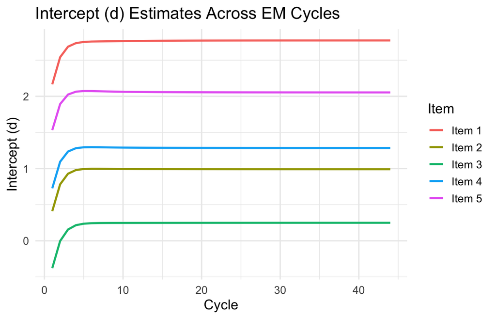

## Watching EM Converge (cont.)

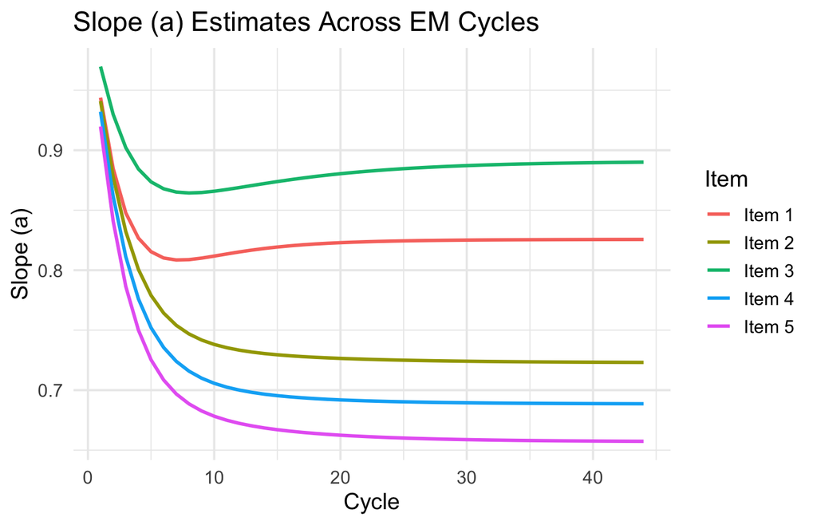

EM converges **slowly** — parameters change rapidly early, then creep toward final values.

## Comparison with `mirt`

Our MMLE/EM vs. mirt Package

| Item | Our \(a\) | mirt \(a\) | Our \(b\) | mirt \(b\) |
| --- | --- | --- | --- | --- |
| 1 | 0.826 | 0.825 | -3.359 | -3.361 |
| 2 | 0.723 | 0.723 | -1.369 | -1.370 |
| 3 | 0.890 | 0.890 | -0.280 | -0.280 |
| 4 | 0.689 | 0.689 | -1.866 | -1.866 |
| 5 | 0.657 | 0.658 | -3.124 | -3.123 |

Small differences reflect implementation details: `mirt` uses 61 quadrature points (vs. our 10) and Bock-Aitkin acceleration.

## EM Algorithm Summary

```
1. INITIALIZE: Starting values for all item parameters

2. E-STEP:
   → Compute likelihood at each node for each response pattern
   → Apply Bayes' theorem to get posterior at each node
   → Aggregate into "artificial data" (n-bar, r-bar)

3. M-STEP:
   → For each item separately:
     Treat artificial data as known, solve for d and a
     using Newton-Raphson

4. CONVERGED? If yes → stop. If no → go to step 2.
```

## Key Takeaways

- **JMLE** estimates every person’s \(\theta\) along with item parameters \(\rightarrow\) inconsistent estimates (Neyman-Scott problem)
- **MMLE** integrates out \(\theta\) by assuming a population distribution \(\rightarrow\) consistent item parameter estimates
- **EM** handles the circular dependency: the E-step infers the ability distribution, the M-step re-estimates item parameters, repeat
- MMLE produces **item parameters only** — person \(\theta\) estimates require a separate step (MLE, MAP, or EAP)